# Hayman Fire Recovery

Matthew Ross

10/3/2019

```r
library(tidyverse)
library(tidyr)
library(ggthemes)
library(lubridate)

# Now that we have learned how to munge (manipulate) data
# and plot it, we will work on using these skills in new ways

knitr::opts_knit$set(root.dir='..')
```

```r
####-----Reading in Data and Stacking it ----- ####
#Reading in files
files <- list.files('../data',full.names=T)
if(length(files) == 0){
  files <- list.files('data',full.names=T)
}

#Read in individual data files
ndmi <- read_csv(files[1]) %>%
  rename(burned=2,unburned=3) %>%
  mutate(data='ndmi')


ndsi <- read_csv(files[2]) %>%
  rename(burned=2,unburned=3) %>%
  mutate(data='ndsi')

ndvi <- read_csv(files[3])%>%
  rename(burned=2,unburned=3) %>%
  mutate(data='ndvi')

# Stack as a tidy dataset
full_long_gather <- rbind(ndvi,ndmi,ndsi) %>%
  gather(key='site',value='value',-DateTime,-data) %>%
  filter(!is.na(value))  %>%
  mutate(month=month(DateTime), year=year(DateTime))

full_long <- rbind(ndvi,ndmi,ndsi) %>%
  pivot_longer(c(-DateTime,-data), names_to='site',values_to='value') %>%
  filter(!is.na(value))  %>%
  mutate(month=month(DateTime), year=year(DateTime))

full_long <- full_long %>% mutate(site_type = ifelse((site == 'unburned'),'Site 1: unburned',ifelse((year(DateTime) >= 2002), 'Site 2: post burn', 'Site 2: pre burn')))


##View(full_long)
```

## NDVI Plot over Time

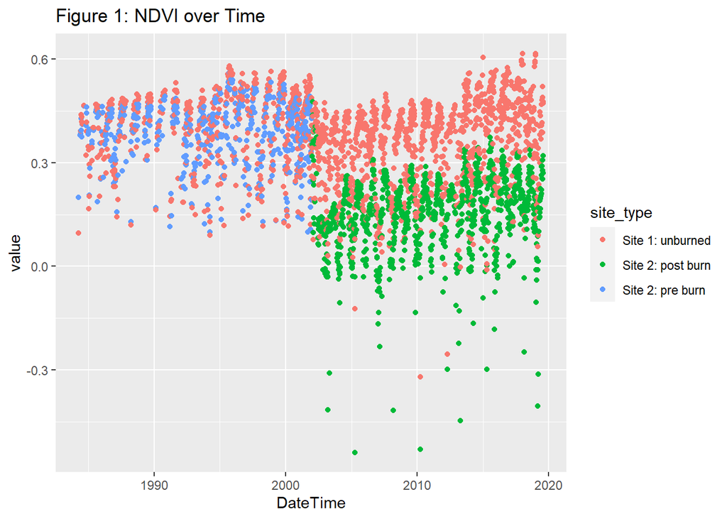

```r
ndvi_plot <- full_long %>%
  filter(data == "ndvi")

ggplot(ndvi_plot,aes(x=DateTime, y=value,color=site_type)) + geom_point() +
    ggtitle('Figure 1: NDVI over Time')
```

```r
#View(ndvi_plot)
```

## Question 1

What is the correlation between NDVI and NDMI? - here I want you to convert the full_long dataset in to a wide dataset using the function “spread” and then make a plot that shows the correlation s a function of if the site was burned or not (x axis should be ndmi) You should exclude winter months and focus on summer months

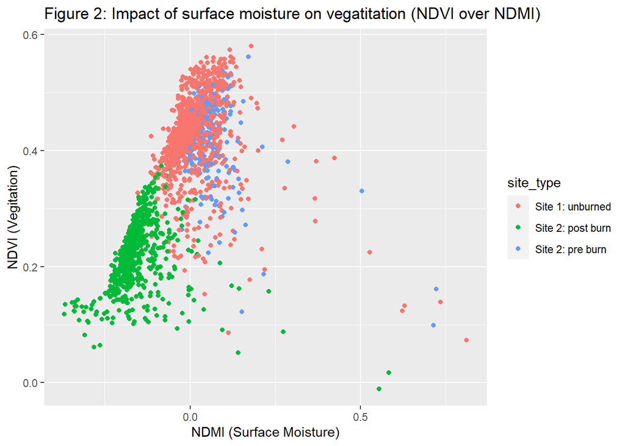

```r
full_wide_spread <- spread(full_long, key=data, value=value, fill = NA, convert = FALSE, drop = TRUE, sep = NULL)

full_wide <- full_long %>% pivot_wider(names_from = data, values_from = value)

full_wide_filtered_notwinter <- full_wide  %>%   filter(!month %in% c(11,12,1,2,3,4))


#View(full_wide_filtered_notwinter)

ggplot(full_wide_filtered_notwinter,aes(x=ndmi, y=ndvi,color=site_type)) + geom_point()+
  ggtitle('Figure 2: Impact of surface moisture on vegatitation (NDVI over NDMI)') +
  scale_x_continuous(name="NDMI (Surface Moisture)") +
  scale_y_continuous(name="NDVI (Vegitation)")
```

### Answer

As surface moisture increases, vegetation increases. Site 2 saw a decrease in surface moisture and vegetation following the same ratio between NDVI and NDMI.

## Question 2

What is the correlation between average NDSI (normalized snow index) for January - April and average NDVI for June-August? In other words, does the previous year’s snow cover influence vegetation growth for the following summer?

```r
## Setup & filter data


## NDSI jan - april  1,2,3,4
ndsi_year <- full_long %>%
  filter(data == "ndsi") %>%
  filter(month %in% c(1,2,3,4)) %>%
  group_by(site_type, year) %>%
  summarize(mean=mean(value), data="ndsi")
## NDVI june - August 6,7,8
ndvi_year <- full_long %>%
  filter(data == "ndvi") %>%
  filter(month %in% c(6,7,8)) %>%
  group_by(site_type, year) %>%
  summarize(mean=mean(value), data="ndvi")
```

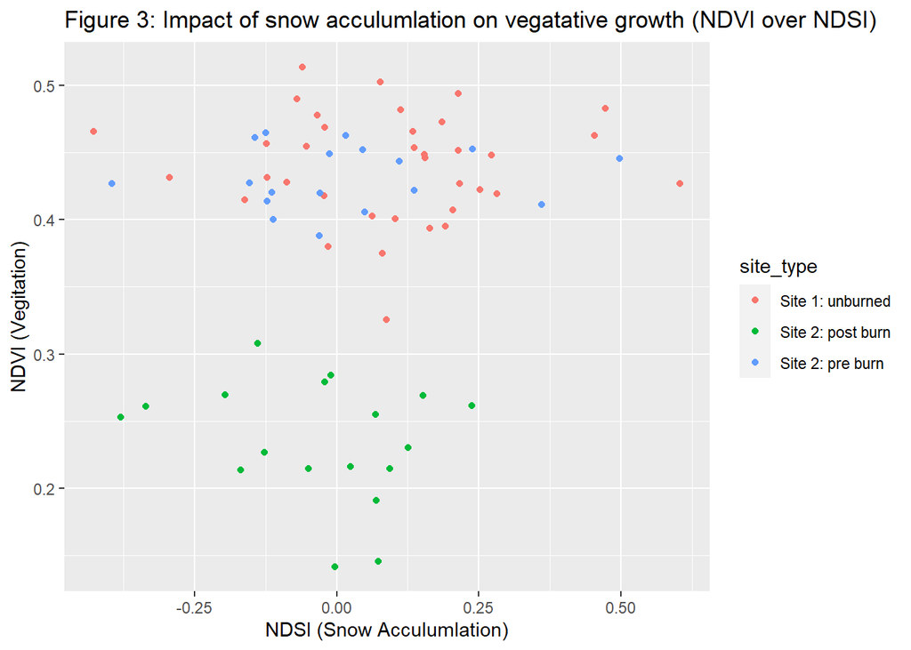

```r
# Stack as a tidy dataset
ndsi_ndvi_year <- rbind(ndsi_year,ndvi_year) %>%
  pivot_wider(names_from = data, values_from = mean)


#(site == 'unburned'),'Site 1: unburned',ifelse((year(DateTime) >= 2002), 'Site 2: post burn', 'Site 1: pre burn')

ggplot(ndsi_ndvi_year,aes(x=ndsi, y=ndvi)) +
  geom_point(aes( color=site_type)) +
  ggtitle('Figure 3: Impact of snow acculumlation on vegatative growth (NDVI over NDSI)')+
  scale_x_continuous(name="NDSI (Snow Acculumlation)") +
  scale_y_continuous(name="NDVI (Vegitation)")
```

### Answer

The previous year’s snow cover has little if any influence on vegetation growth the following summer. Both for the Site 1 & Site 2 pre burn.

## Q3

How is the snow effect from question 2 different between pre- and post-burn and burned and unburned?

### Answer

There is a clear shift in vegetation due to the impacts of burned areas as seen in **Figure 3**. Site 2: post burn has a slightly negative slop indicating that snow fall has a negative impact on vegetation the following year if the ground was recently burned.

## Question 4

What month is the greenest month on average?

```r
ndvi_month_avg <- full_long %>%
  filter(data == "ndvi") %>%
  group_by(month) %>%
  summarize(mean=mean(value), data="ndvi")%>%
  pivot_wider(names_from = data, values_from = mean)

ndvi_month <- full_long %>%
  filter(data == "ndvi") %>%
  group_by(site_type, month) %>%
  summarize(mean=mean(value), data="ndvi")%>%
  pivot_wider(names_from = data, values_from = mean)
```

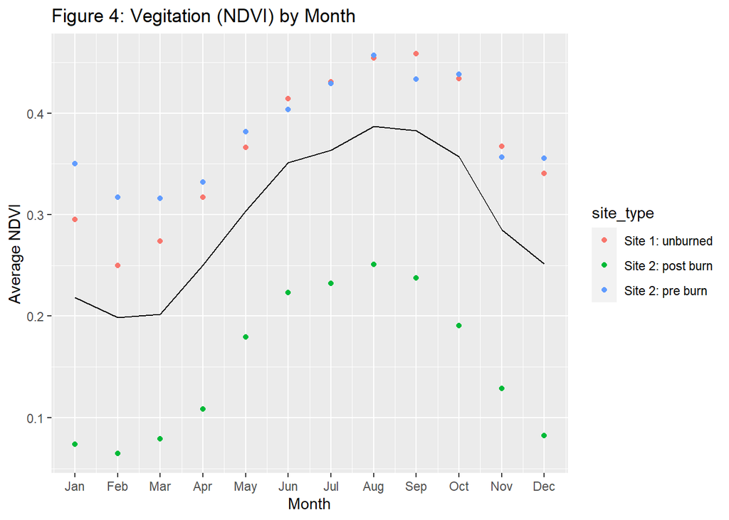

```r
ggplot() +
  geom_line(data = ndvi_month_avg, aes( x=month, y=ndvi)) +
  geom_point(data = ndvi_month, aes(x=month, y=ndvi, color=site_type)) +
  ggtitle('Figure 4: Vegitation (NDVI) by Month')+
  scale_x_continuous(name="Month",   breaks = c(1,2,3,4,5,6,7,8,9,10,11,12),
  label = c("Jan", "Feb", "Mar", "Apr","May","Jun","Jul","Aug","Sep","Oct","Nov","Dec")) +
  scale_y_continuous(name="Average NDVI")
```

## Question 5)

What month is the snowiest on average?

```r
ndsi_month_avg <- full_long %>%
  filter(data == "ndsi") %>%
  group_by(month) %>%
  summarize(mean=mean(value), data="ndsi")%>%
  pivot_wider(names_from = data, values_from = mean)


ndsi_month <- full_long %>%
  filter(data == "ndsi") %>%
  group_by(site_type, month) %>%
  summarize(mean=mean(value), data="ndsi")%>%
  pivot_wider(names_from = data, values_from = mean)
```

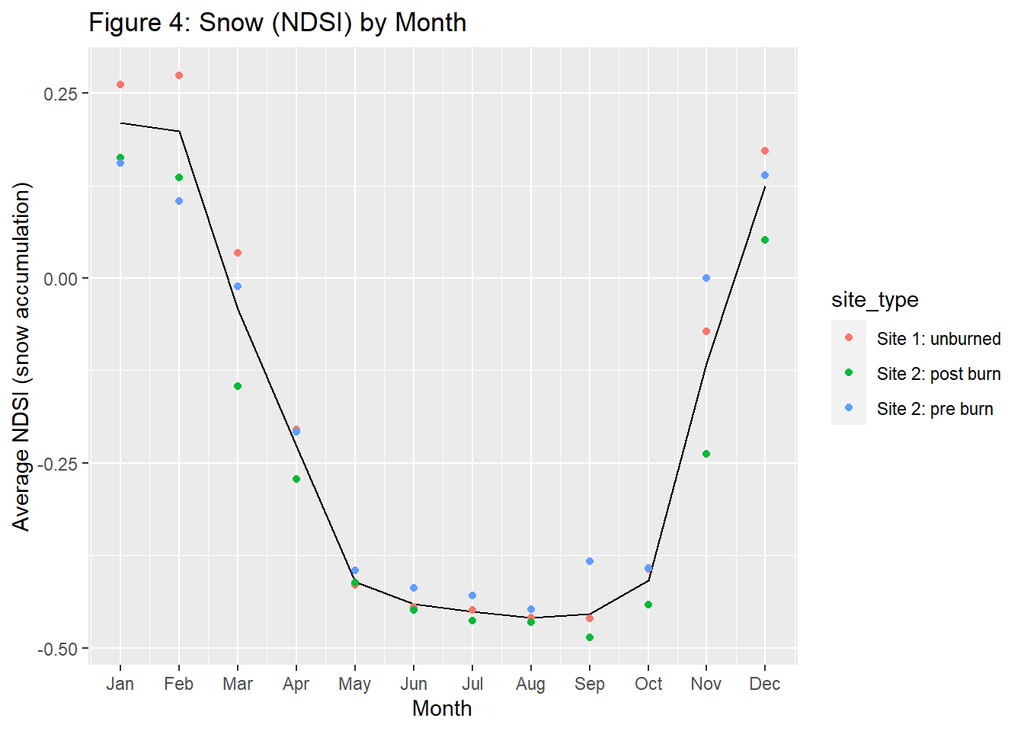

```r
ggplot() +
  geom_line(data = ndsi_month_avg, aes( x=month, y=ndsi)) +
  geom_point(data = ndsi_month, aes(x=month, y=ndsi, color=site_type)) +
  ggtitle('Figure 4: Snow (NDSI) by Month')+
  scale_x_continuous(name="Month",   breaks = c(1,2,3,4,5,6,7,8,9,10,11,12),
  label = c("Jan", "Feb", "Mar", "Apr","May","Jun","Jul","Aug","Sep","Oct","Nov","Dec")) +
  scale_y_continuous(name="Average NDSI (snow accumulation)")
```

## Bonus Question: Redo all problems with `spread` and `gather` using modern tidyverse syntax.

[Article on topic](https://www.findingyourway.io/blog/2019/09/18/2019-09-18-tidyr-1-0-gather-and-spread-are-dead/)

-[x] complete

### Gather

df %>% gather(“key”, “value”, x, y, z) is equivalent to df %>% pivot_longer(c(x, y, z), names_to = “key”, values_to = “value”)

Below is old code, code above has been replaced

```r
full_long_gather <- rbind(ndvi,ndmi,ndsi) %>%
  gather(key='site',value='value',-DateTime,-data) %>%
  filter(!is.na(value))  %>%
  mutate(month=month(DateTime), year=year(DateTime))
```

### Spread

df %>% spread(key, value) is equivalent to df %>% pivot_wider(names_from = key, values_from = value)

Below is old code, code above has been replaced

```r
full_wide_spread <- spread(full_long, key=data, value=value, fill = NA, convert = FALSE, drop = TRUE, sep = NULL)
```

## Bonus Question: Use Climage Engine to pull the same data for the assignment, but updated with 2020/2021 data.